# Effects of sediment on the recruit survival of juvenile corals

Lillian J. Tuttle

9/25/2020

These datasets contain information from multiple articles (**Ref_name**) and studies/experiments (**Ref**) within those articles about the effects of DEPOSITED sediment on the **recruit survival rate** of juvenile corals. I would like to explore the dose-response relationship between sediment ‘dose’ and the effect size, estimated here as the standardized mean difference between treatment and control, in terms of Hedges’ *d*:

- Hedges’ *d* is the standardized mean difference between the treatment and control groups (Hedges and Olkin 1985). Each study may have multiple Hedges’ *d* calculations, one for each treatment-control comparison at each time-point.
- ‘Dose’ can be quantified as sediment exposure concentration (mg/cm<sup>2</sup>/day), exposure duration (days), or as “cumulative exposure”, for which I multiply concentration and duration (mg/cm<sup>2</sup>).

Each study/experiment (Ref) may contain multiple sets of controls and treatments (due to using multiple species or sediment types, for instance). Thus, I have added two categorical vectors, ‘**Comparison**’ and ‘Control’, which group each set of control-treatment comparisons into a unique two-letter code, within which is one control (Control==“1”) and at least one treatment (Control==“0”). **Therefore, ‘Comparison’ is nested within ‘Ref’, which is further nested within ‘Ref_name’.**

# I. Recruit Survival Rate

## A. Deposited Sediment

### 1. Plots

I calculated the standardized mean difference in terms of Hedges’ *d* and plot it here with respect to exposure concentration. I did this first for a Hedges’ *d* that I calculated before importing the data to R and again for a Hedges’ *d* that is calculated by the dosresmeta::covar.smd function.

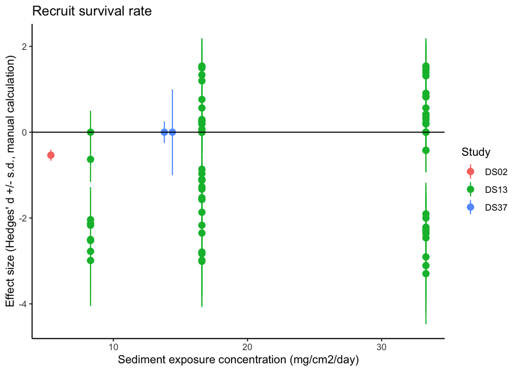

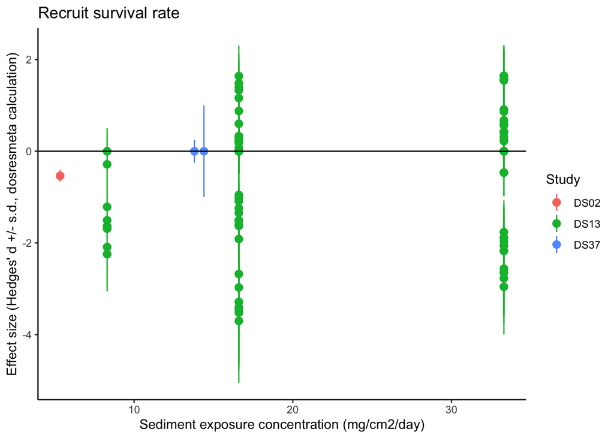

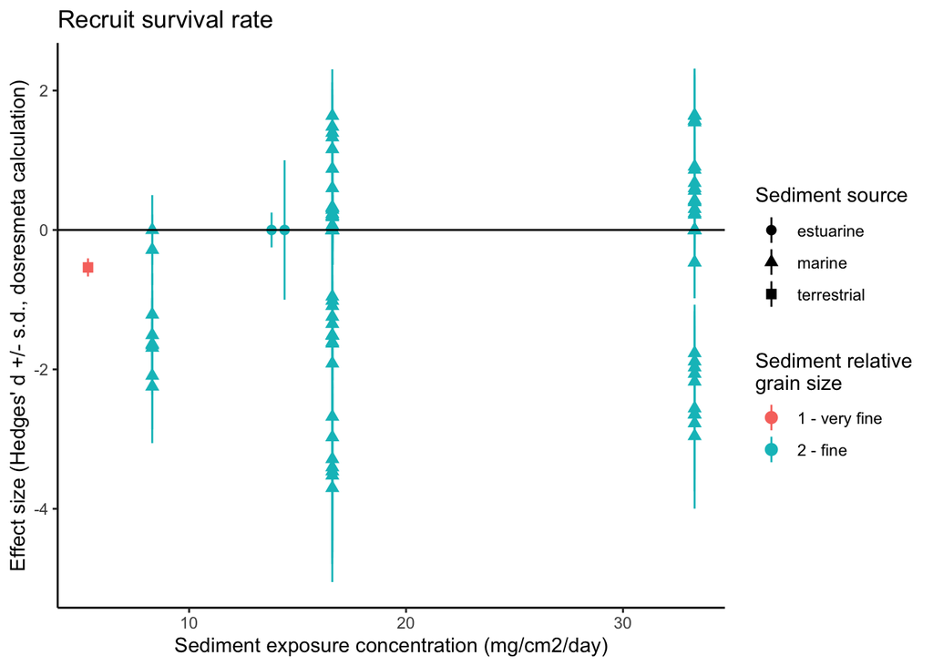

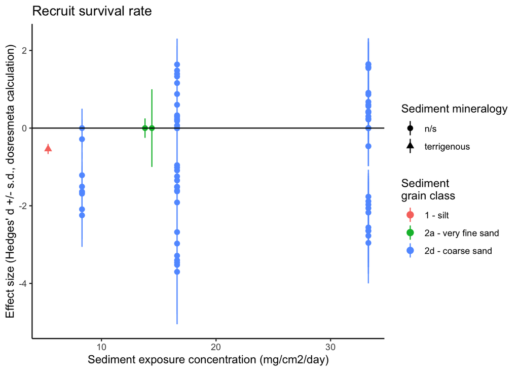

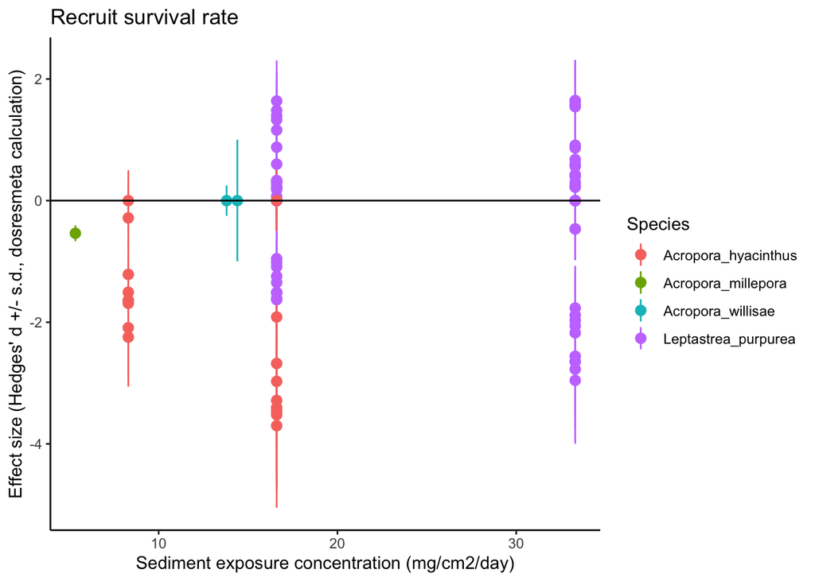

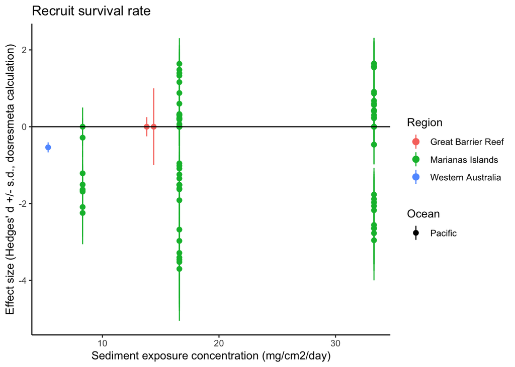

It is interesting that there is a difference between how I calculated Hedges’ *d* and how *dosresmeta* appears to calculate it. But in both cases, there does not appear to be an effect of sediment exposure on effect size, except for *Acropora hyacinthus*, for which there appears to be a strong effect of sediment on effect size. There is not a discernible effect of geography (ocean and region) because almost all of the data were from the Marianas Islands. I still need to investigate the effects of sediment type (source, origin, grain size).

### 2. Model Fitting

The following set of functions model fixed and random (nested) effects WITHOUT accounting for within-comparison (or within-study) correlations. The output for each is a univariate, random-effects meta-regression.

To account for within-comparison correlations in the mixmeta model, I replace the ‘S’ argument with a ‘control’ argument, which requires me to provide the covariance matrices, as done with the covar.smd function.

And now to compare relative fit of linear models…

```
##                   df      AIC
## mod_DS_recruit_1d  5 261.0143
## mod_DS_recruit_2d  8 267.0143
## mod_DS_recruit_5d  5 234.4904
## mod_DS_recruit_6d  8 240.4904
```

And now to evaluate residuals of models…

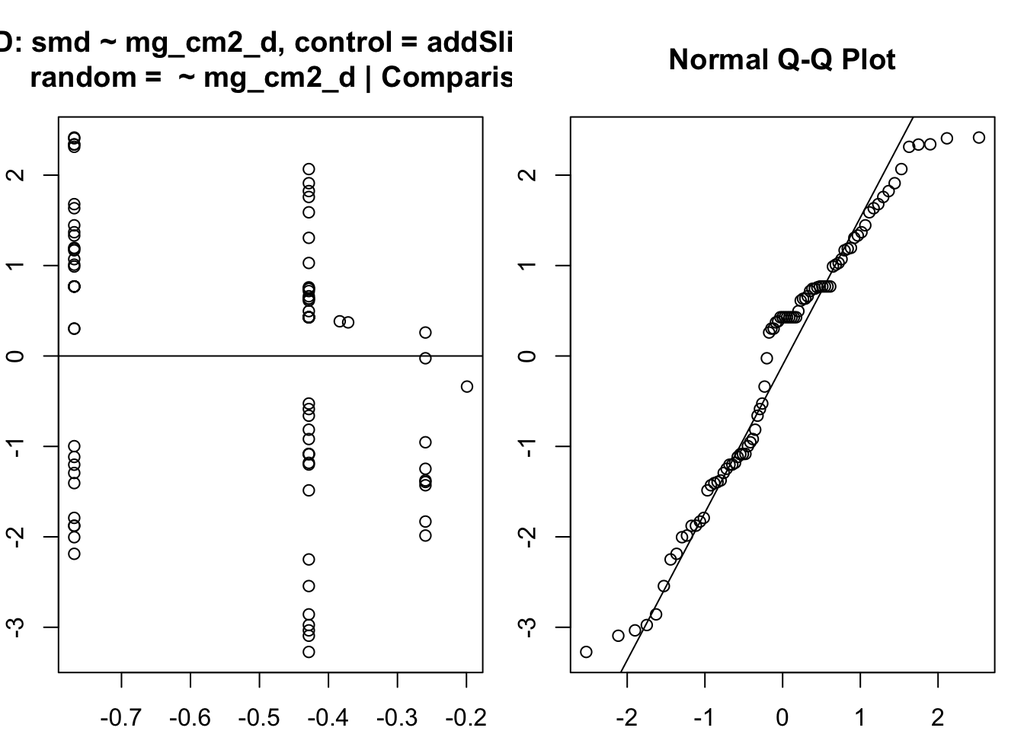

### 3. Best-Fit Model Summary

#### MG/CM2/DAY IS PREDICTOR, Model using dosresmeta calculation of Hedges’ *d*

Now I will predict the effect size along the exposure range and plot with confidence intervals.

```
## Call:  mixmeta(formula = smd ~ Sed_level_standardized, data = ES_DS_recruit2,
##     random = ~Sed_level_standardized | Comparison, method = "ml",
##     control = list(addSlist = newlist_REC))
##
## Univariate extended random-effects meta-regression
## Dimension: 1
## Estimation method: ML
##
## Fixed-effects coefficients
##                         Estimate  Std. Error        z  Pr(>|z|)  95%ci.lb
## (Intercept)              -0.0904      0.1849  -0.4890    0.6248   -0.4529
## Sed_level_standardized   -0.0204      0.0091  -2.2410    0.0250   -0.0382
##                         95%ci.ub
## (Intercept)               0.2720
## Sed_level_standardized   -0.0026  *
## ---
## Signif. codes:  0 '***' 0.001 '**' 0.01 '*' 0.05 '.' 0.1 ' ' 1
##
## Random-effects (co)variance components
##  Formula: ~Sed_level_standardized | Comparison
##  Structure: General positive-definite
##                         Std. Dev         Corr
## (Intercept)               0.3542  (Intercept)
## Sed_level_standardized    0.0332            1
##
## Univariate Cochran Q-test for residual heterogeneity:
## Q = 160.7006 (df = 85), p-value = 0.0000
## I-square statistic = 47.1%
##
## 87 units, 1 outcome, 87 observations, 2 fixed and 3 random-effects parameters
##    logLik        AIC        BIC
## -112.2452   234.4904   246.8199
```

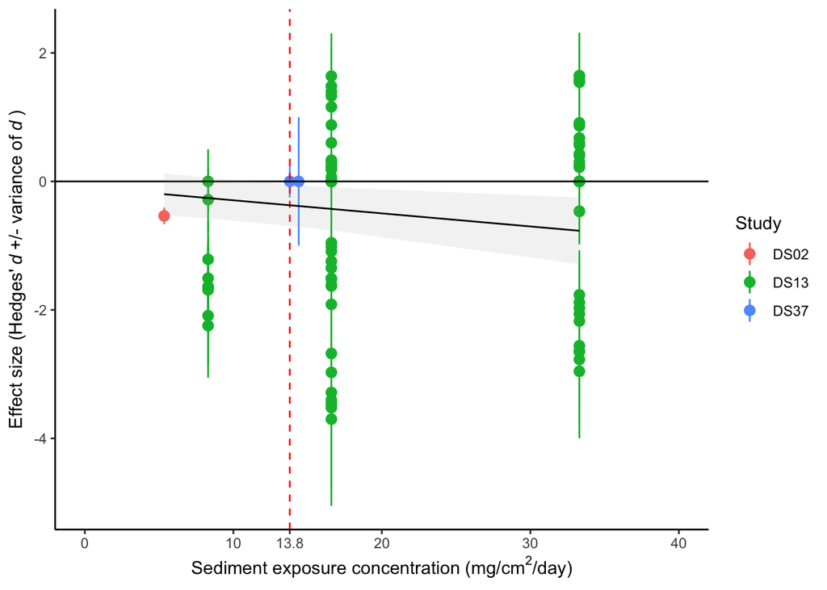